# Tax Changes Template

Jack Landry

5/24/2021

## Explanation of Reform

What does the reform look like? Here, I pick pretty arbitrary numbers to remove the phase in, increase the max benefit, and increase the phase out threshold. I didn’t touch the phase out rate (double check), should I do that in the future? I think I want to add lines for married filers, as well as a comparison to the status-quo EITC. Maybe add some light gray lines for the status-quo? Labels might get messy.

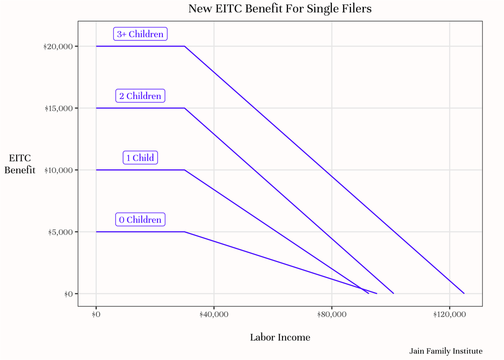

Should maybe add how post-tax income varies with labor income pre-post reform by number of kids.

## Poverty Impacts of Expanded EITC

Calculating changes in poverty from random changes to the EITC I made up. Note that poverty measure is at the HH level, and most categories would be at the individual level.

| Group | Status Quo Poverty | EITC Reform Poverty | Poverty Reduction |
| --- | --- | --- | --- |
| Overall | 13.9% | 7.5% | 6.3% |
| Children | 15.5% | 5.3% | 10.2% |

This reform caused a 19,992,189 household poverty reduction, a 45.6% decrease (a 6.3 percentage point reduction). Need to be careful with HH vs. individual level.

## Deep Poverty Impacts of Expanded EITC

| Group | Status Quo Deep Poverty | EITC Reform Deep Poverty | Deep Poverty Reduction |
| --- | --- | --- | --- |
| Overall | 4.9% | 2.7% | 2.3% |
| Children | 4.8% | 1.1% | 3.7% |

## Effects Across the Income Distribution

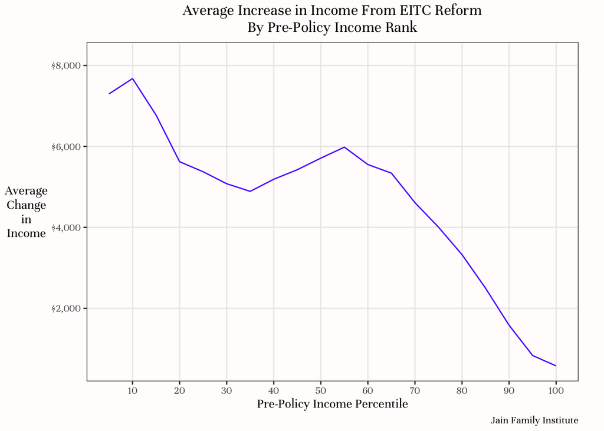

Should do analysis for different groups, e.g. number of children (that’s a HH thing), labor force status, race, more?

## Cost of Reform

I think the “total tax revenue” is probably way off due to CPS not being representative of top incomes, so probably should just say the cost rather than including this table with the overall numbers. (The cost difference should be pretty accurate because all the changes are with the low income filers)

| Status Quo Tax Revenue | Total Tax Revenue Reform | Cost of Reform |
| --- | --- | --- |
| $1346 | $857 | $-489 |

Note: Cost in Billions of Dollars